# GMRI R Style Doc

# Accessing GMRI styles

This package contains various functions for quickly accessing GMRI styles, colors, and themes.

## Adding a Header

The function: `insert_gmri_header()` was created to insert a header file into an rmarkdown document or shiny app. This function was conceived to work by printing an html file located in the `gmRi/inst/stylesheets` directory in-place into the .Rmd or shiny file. Currently it only works succesfully with shiny apps.

This function should be run in the first code block in the document, prior to any outputs or text. The html header will be inserted in place, so any text above it will remain above it.

Currently this function fails for rmarkdown files because it is unable to locate the .png file for the logo to display correctly. Perhaps a friendly collaborator could remedy this…

An alternative way to add a header is by including it in the `www` subfolder of a .Rmd file. Then in the YAML header it can be referenced directly with:

`output:`  
`html_document:`  
`includes:`  
`in_header: www/header.html`  
`before_body: www/doc_prefix.html`  
`after_body: www/doc_suffix.html`

If it references an image file make sure the path is also `www/image.png` and that the file is in that folder.

OR alternatively you can add html, or images directly by including it directly via a path to a subfolder and referencing them in the subfolder.

**Example:** The following line of html code will attach the GMRI logo to the right of the document, the top-right when included at the start of an .Rmd doc.

```r
<img src='www/gmri_logo.png' align="right" height="44" />
```

## Attaching CSS File from gmRi Package

The CSS file determines what fonts, colors, sizes, spacing, and margins should be applied to different elements throughout the document. The default css file will apply the GMRI font to the headers, and apply some GMRI colors to various rmarkdown elements.

This can be placed anywhere in the document **except** in the setup code block. It is helpful to place this line of code with other formatting options near the top of the document.

```r
# Access GMRI CSS Style
gmRi::use_gmri_style_rmd(css_file = "gmri_rmarkdown.css")
```

An alternative function `use_gmri_style_shiny` exists for linking a stylesheet to a Shiny Application. This function has two alternative calls for attaching a header or footer as well.

## Including GMRI Colors in Plots

You can also access GMRI colors in ggplot through some additional functions for accessing brand colorways.

### Discrete Colors Manually

Available GMRI colors can be accessed by running `gmri_cols()` without any arguments. This function can also be used to return the hex values of a desired color by name. This is helpful for manual insertion of specific colors.

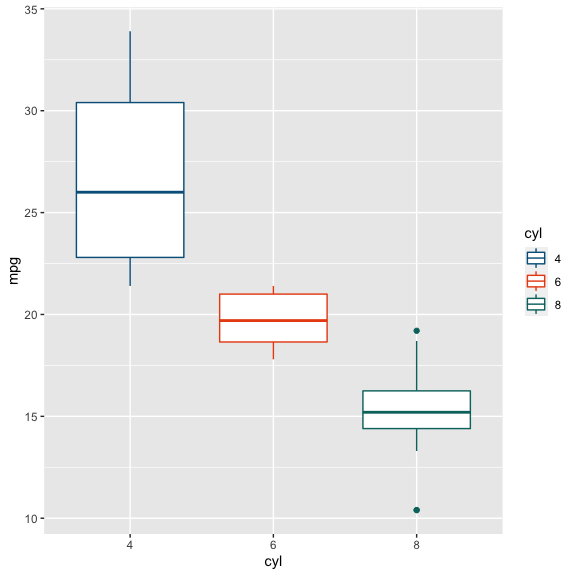

```r
mtcars$car <- rownames(mtcars)
mtcars$cyl <- factor(mtcars$cyl)

ggplot(mtcars, aes(cyl, mpg, color = cyl)) +
  geom_boxplot() +
  scale_color_manual(
    values = setNames(gmri_cols(c("gmri blue", "orange", "teal"), as_char = TRUE),
                      c("4", "6", "8"))
  )
```

### Interpolated Colors

There are also 2 functions for interpolating colors using several palettes, these are `scale_fill_gmri()` and `scale_color_gmri()`.

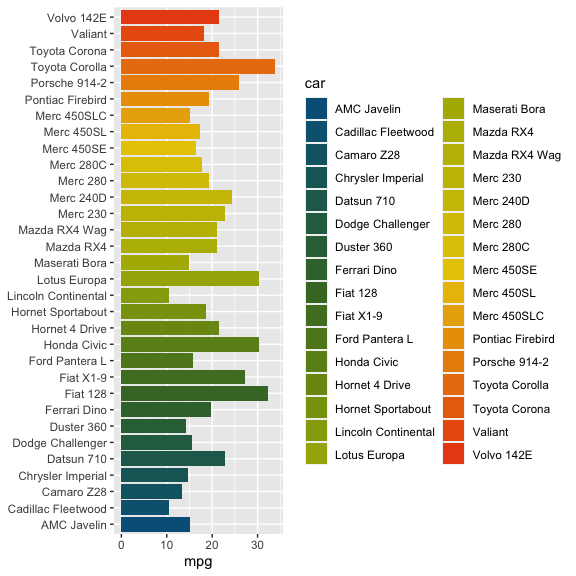

```r
ggplot(mtcars, aes(mpg, car, fill = car)) +
  geom_col() +
  scale_fill_gmri() +
  labs(y = NULL)
```

## Adding a Footer

One way to add personalization is through a custom footer file. This file is written in HTML and can be attached to the bottom of the ddocument for a personalized footer. The default is an example that uses the github logo and a link to a personal github account.

```r
# footer
gmRi::insert_gmri_footer(footer_file = "akemberling_gmri_footer.html")
```

A work by [Adam A. Kemberling](https://github.com/adamkemberling/)

*Akemberling@gmri.org*